# Understanding proposal win rates

Martijn Schroder

1/05/2019

# Executive summary

In management consulting competitiveness is high. Our firm competes actively with the ‘Big 4’ consultancies. Better understanding of the reasons why we win and loose proposal will give us an advantage.

Our business makes decisions on our proposal management practice with the view to increase win rates. Until recently those decisions were made based on experience and perception of what works and what doesn’t.

In this assignment my aim is to try machine learning approaches to gain insights into what the data tells us about the relevant features that are good predictors of win and lose rates.

Given the low number of transactions and limited cleanliness of the data, the analysis of features that should underpin decisions around proposals is relatively ambiguous. This is the main challenge to work with.

> For obvious reasons the data is de identified and various columns have been recoded. This part of the data wrangling has not been shown.

# Cleaning data

The data set is a raw export from the system we use to manage opportunities. A csv export was obtained, which after de identification has the following structure:

```r
str(proposals, give.attr = FALSE) # show structure of data
```

```
## Classes 'spec_tbl_df', 'tbl_df', 'tbl' and 'data.frame': 2821 obs. of  14 variables:
##  $ account        : chr  "account755" "account253" "account541" "account743" ...
##  $ stage          : num  1 1 1 1 0 0 0 1 1 1 ...
##  $ amount         : num  81735 99134 0 220000 150000 ...
##  $ creationDate   : chr  "10/3/18" "4/8/16" "13/3/18" "9/3/18" ...
##  $ closeDate      : chr  "9/6/18" "19/8/16" "17/7/18" "12/4/18" ...
##  $ practice       : chr  "practice3" "practice4" "practice4" "practice1" ...
##  $ offer          : chr  "offer37" "offer44" "offer44" "offer54" ...
##  $ sector         : chr  "sector2" "sector4" NA NA ...
##  $ segment        : chr  "segment25" "segment19" "segment27" "segment25" ...
##  $ director       : chr  "director92" "director131" "director124" "director143" ...
##  $ manager        : chr  "manager148" "manager17" "manager245" "manager313" ...
##  $ source         : chr  NA "source2" NA "source5" ...
##  $ competitiveness: chr  NA NA NA NA ...
##  $ code           : chr  "UOW" "DHV" "NUK" "UNS" ...
```

## Description of dataset

The meaning of the columns is as follows:

| Column | Explanation |
| --- | --- |
| account | Name of the account, i.e. the client |
| stage | Proposal win / loss (1 = win, 0 = loss) |
| amount | Estimated value of the opportunity |
| creationDate | Creation date of the record |
| closeDate | Close date of the record |
| practice | High level practice group for the opportunity |
| offer | Business offer the opportunity falls under (e.g. analytics, consulting, project management) |
| sector | Sector of business the client falls under (e.g. education, health, finance) |
| segment | Segment of the sector the opportunity falls under (e.g. insurance or loans for sector finance |
| director | Proposal director; in our practice we assign a proposal director and manager to each proposal |
| manager | Proposal manager |
| source | Source of the opportunity, i.e. how did we know of it (e.g. approached by client, tender |
| competitiveness | Level of competitiveness of the opportunity (i.e. are we only party bidding or are there more?) |
| code | Three letter code significing the account |

## Fixing data formats

The data needs cleaning up. The following changes are made:

- Convert “amount” column from num to double
- Convert “creationDate” and “closeDate” to Date format

```r
# re code data types
proposals$amount <- as.double(proposals$amount)
proposals$creationDate <- as.Date(proposals$creationDate, "%d/%m/%y")
proposals$closeDate <- as.Date(proposals$closeDate, "%d/%m/%y")
```

# Exploration

## Exploration of columns

Some basic exploration of the columns to better understand what information is useful, given business rules.

## Data integrity

The figure below shows the proportion of NA values in the columns of the dataset.

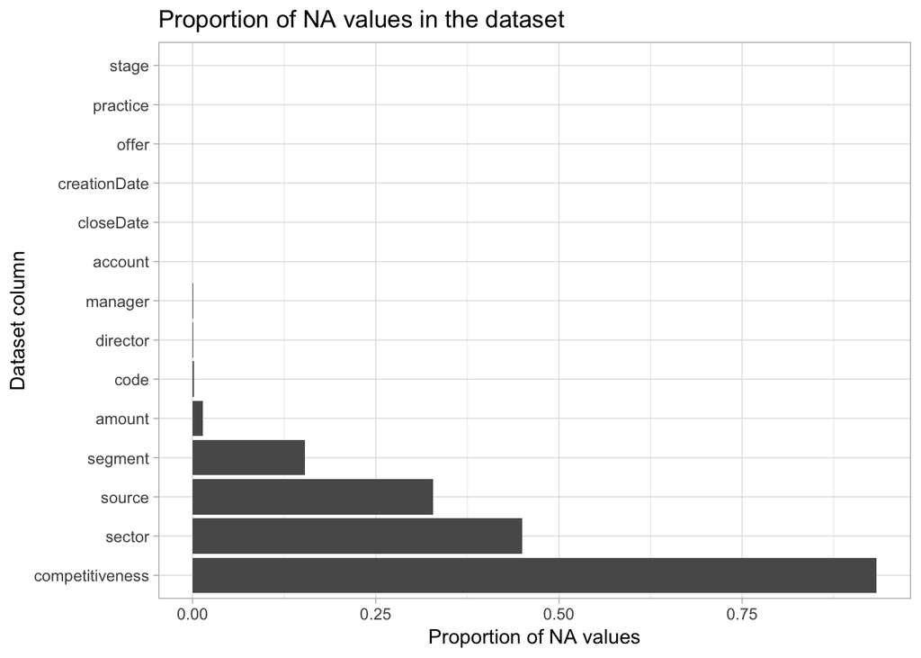

The following approaches to addressing the NA values are implemented:

- *competitiveness*: drop the column. Although it would be interesting to see the impact of competitiveness on proposals, too many data points are missing to make it useful in the overall analysis. Business practice changes will need to ensure this data is consistently gathered going forward

```r
proposals <- proposals %>% select(-competitiveness)
```

- *Amount*: Replace missing amounts with overall mean for amount, or if group means can be used (e.g. group means for *offer*). First look at the distribution:

```r
summary(proposals$amount)
```

```
##    Min. 1st Qu.  Median    Mean 3rd Qu.    Max.    NA's
##       0   15750   50000  107032  120000 4000000      39
```

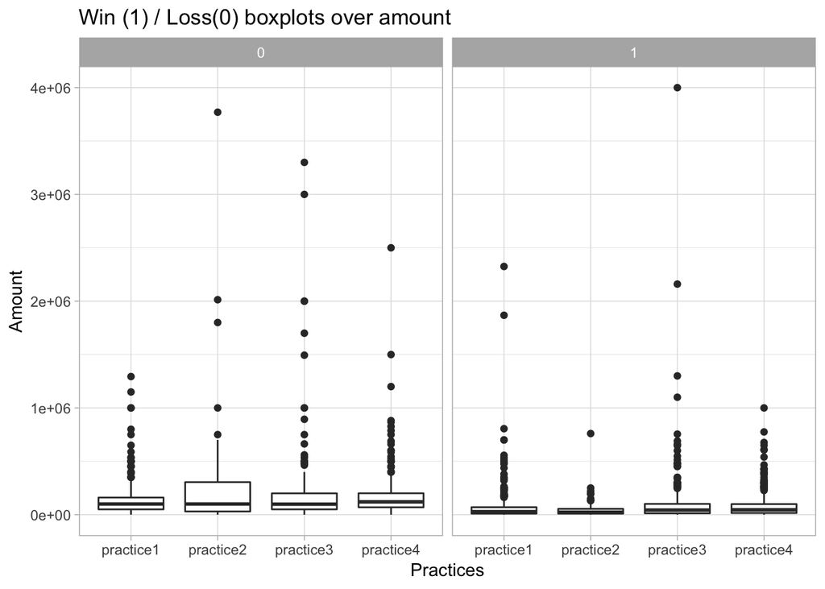

```r
proposals %>%
  ggplot(aes(practice, amount)) +
  geom_boxplot() +
  theme_light() +
  facet_wrap(~stage, ncol=2) +
  ggtitle("Win (1) / Loss(0) boxplots over amount") +
  xlab("Practices") +
  ylab("Amount")
```

```r
amounts <- as.double(proposals$amount[!is.na(proposals$amount)])
avg_amount <- mean(amounts[amounts > 999]) # calculate overall avg with values greater than 999
proposals$amount[is.na(proposals$amount)] <- avg_amount # replace NAs with avg amount
proposals$amount[proposals$amount <= 999] <- avg_amount # replace amounts < 999 with avg_amount
rm(amounts, avg_amount)
```

```r
proposals$sector[is.na(proposals$sector)] <- "unknown"
```

## Data exploration

First some basic exploration of the data to get an understanding of what it tells us.